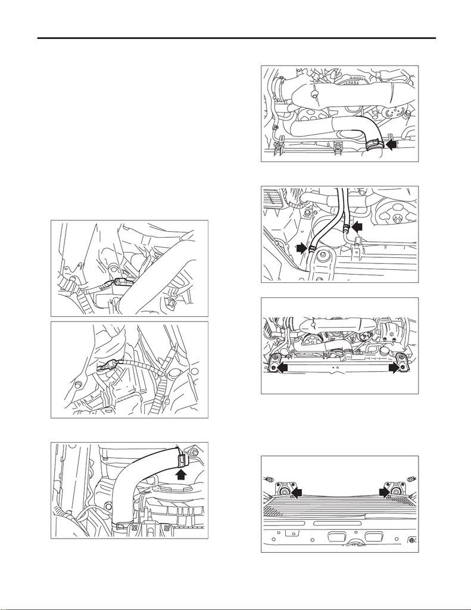

CO(STI)-19

Radiator

COOLING

6. Radiator

A: REMOVAL

CAUTION:

The radiator is pressurized when the engine

and radiator are hot. Wait until engine and radi-

ator cool down before working on the radiator.

1) Disconnect the ground cable from battery.

2) Remove the air intake duct. <Ref. to IN(STI)-11,

REMOVAL, Air Intake Duct.>

3) Remove the reservoir tank. <Ref. to CO(STI)-27,

REMOVAL, Reservoir Tank.>

4) Drain engine coolant. <Ref. to CO(STI)-13,

DRAINING OF ENGINE COOLANT, REPLACE-

MENT, Engine Coolant.>

5) Disconnect the connector (A) from the main fan

motor and the connector (B) from the sub fan mo-

tor.

6) Disconnect the radiator outlet hose from thermo-

stat cover.

7) Lower the vehicle.

8) Disconnect the radiator inlet hose from the radi-

ator.

9) Disconnect the two engine coolant hoses from

the radiator and over flow pipe.

10) Remove the radiator upper brackets.

11) Move the radiator to the left while lifting it up-

ward.

12) Lift the radiator up and remove the radiator

from vehicle.

13) Remove the radiator lower cushion from the ra-

diator lower bracket.

(A)

CO-02727

(B)

CO-02728

CO-02771

CO-02712

CO-02713

CO-03369

CO

-03353

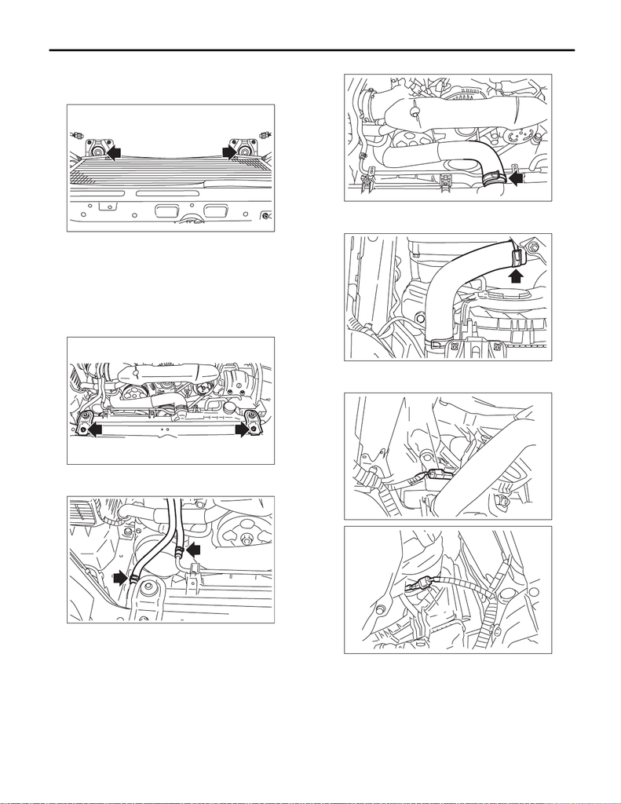

CO(STI)-20

Radiator

COOLING

B: INSTALLATION

1) Attach the radiator lower cushion to the radiator

lower bracket.

2) Install the radiator to vehicle.

NOTE:

Make pins on the lower side of radiator be fitted into

the radiator lower cushions.

3) Install the radiator upper brackets.

Tightening torque:

12 N·m (1.2 kgf-m, 8.9 ft-lb)

4) Connect the two engine coolant hoses to the ra-

diator and over flow pipe.

5) Connect the radiator inlet hose.

6) Lift up the vehicle.

7) Connect the radiator outlet hose.

8) Connect the connector (A) to the main fan motor

and the connector (B) to the sub fan motor.

10) Lower the vehicle.

11) Install the reservoir tank. <Ref. to CO(STI)-27,

INSTALLATION, Reservoir Tank.>

12) Install the air intake duct. <Ref. to IN(STI)-11,

INSTALLATION, Air Intake Duct.>

13) Connect the battery ground terminal.

CO

-03353

CO-03369

CO-02713

CO-02712

CO-02771

(A)

CO-02727

(B)

CO-02728

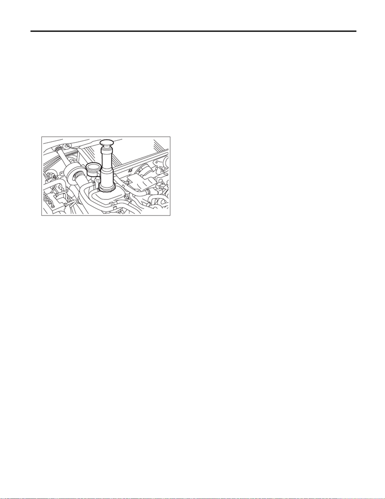

CO(STI)-21

Radiator

COOLING

14) Fill engine coolant. <Ref. to CO(STI)-13, FILL-

ING OF ENGINE COOLANT, REPLACEMENT,

Engine Coolant.>

C: INSPECTION

1) Check that the radiator does not have deforma-

tion, cracks or damage.

2) Check that the hose has no cracks, damage or

loose part.

3) Remove the coolant filler tank cap, fill the cool-

ant filler tank with engine coolant, then install the

radiator cap tester to the filler neck of coolant filler

tank.

4) Apply a pressure of 122 kPa (1.2 kg/cm

2

, 18 psi)

to the radiator and check the following points:

• Leakage from the radiator or its vicinity

• Leakage from the hose or its connections

CAUTION:

• Inspection must be carried out at the side of

coolant filler tank, not at the side of radiator.

• Engine should be turned off.

• Wipe engine coolant from check points in ad-

vance.

• Be careful not to deform the filler neck of the

coolant filler tank when installing and removing

the radiator cap tester.

• Be careful of engine coolant from spurting

out when removing the radiator cap tester.

CO-03377